# Dynatrace Analytics Workshop - EDA

# Data import

Import data in list via function Calll to import_csv_data().

```r
data <- import_csv_data(path = "Olist_data/")
```

# Analysis of Purchase-Behavior over time

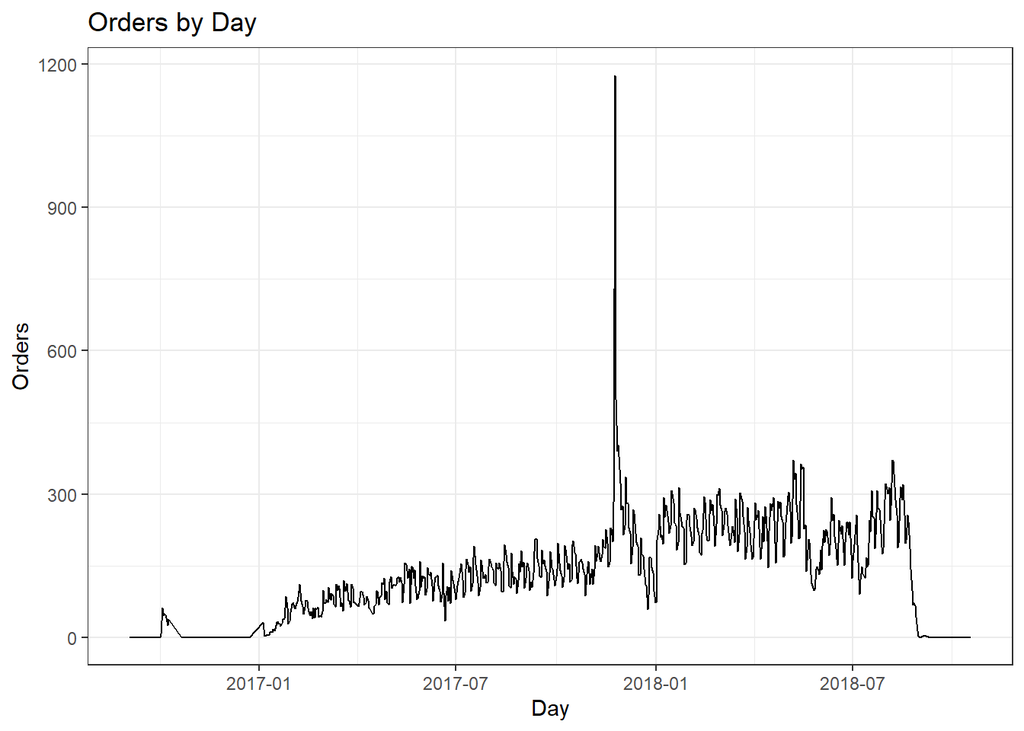

```r
data[[6]] %>%
  mutate(order_purchase_date = as_date(order_purchase_timestamp)) %>% #date of purchase
  group_by(order_purchase_date) %>% #group by date of purchase
  count() %>% #summarize
  arrange(order_purchase_date) %>%
  ggplot(., aes(x = order_purchase_date, y = n)) +
  geom_line() + #line plot
  theme_bw() +
  labs(x = "Day", y = "Orders", title = "Orders by Day")
```

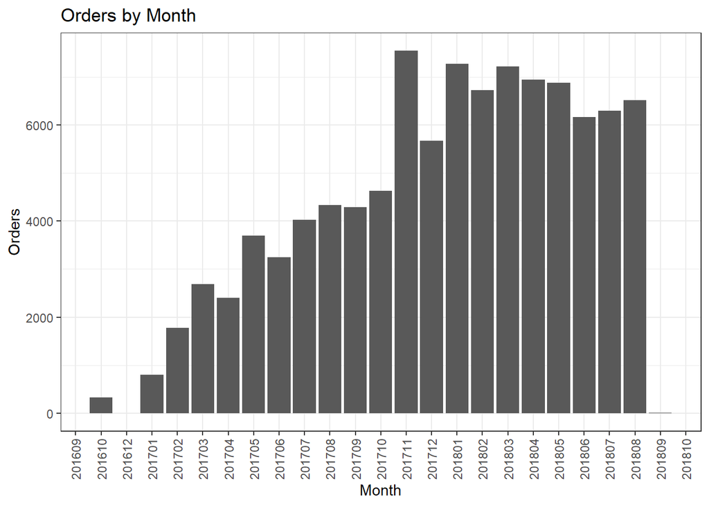

```r
data[[6]] %>%
  mutate(order_purchase_month = format.Date(order_purchase_timestamp, "%Y%m")) %>% #month of purchase
  group_by(order_purchase_month) %>% #group by date of purchase
  count() %>% #summarize
  arrange(order_purchase_month) %>%
  ggplot(., aes(x = order_purchase_month, y = n)) +
  geom_col() + #barplot
  theme_bw() +
  labs(x = "Month", y = "Orders", title = "Orders by Month") +
  theme(axis.text.x = element_text(angle = 90, vjust = 0.5, hjust=1))
```

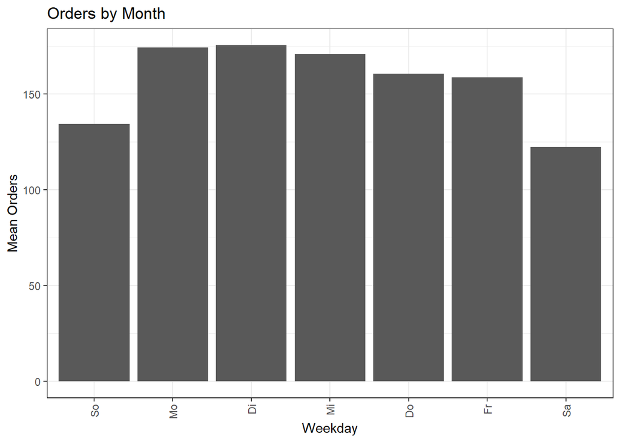

```r
data[[6]] %>%
  mutate(order_purchase_date = as_date(order_purchase_timestamp)) %>% #date of purchase
  group_by(order_purchase_date) %>% #group by date of purchase
  count() %>% #summarize
  mutate(order_purchase_wday = wday(order_purchase_date, label = TRUE)) %>%  #weekday of purchase
  group_by(order_purchase_wday) %>%
  summarize(mean_order = mean(n)) %>%
  ggplot(., aes(x = order_purchase_wday, y = mean_order)) +
  geom_col() + #barplot
  theme_bw() +
  labs(x = "Weekday", y = "Mean Orders", title = "Orders by Month") +
  theme(axis.text.x = element_text(angle = 90, vjust = 0.5, hjust=1))
```

Data Anomalies:

- Only a few purchases from September to October 2016
- Outlier on 2017-11-24 with 1,176 Orders (No other day with more than 500 Orders)
- Heavily decreasing number of parchases With end of August 2018 -> Probably due to time lag between order and delivery

We observe a heavy growth in Orders up until January 2018 with a stagnation in 2018. There seems to be a weekly saisonality with less Orders on the weekend and most Orders at the beginning of the week on Monday and Tuesday.

# Forecasting of daily Orders

## Data Clean-Up

To increase data quality, all data points before 2017-01-01 and after 2018-08-01 are excluded. Additionally the observation 2017-11-24 with 1,176 Orders is excluded to prepare the data for the forecasting algorithm.

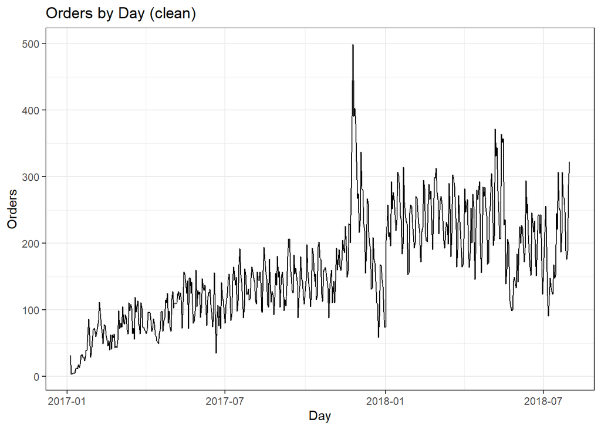

```r
daily_orders <- data[[6]] %>%
  mutate(order_purchase_date = as_date(order_purchase_timestamp)) %>% #date of purchase
  group_by(order_purchase_date) %>% #group by date of purchase
  count() %>% #summarize
  filter(order_purchase_date > "2017-01-01" &
           order_purchase_date < "2018-08-01" & #exclude months with missing data
           order_purchase_date != "2017-11-24") #exclude anomaly

daily_orders %>%
  ggplot(., aes(x = order_purchase_date, y = n)) +
  geom_line() + #line plot
  theme_bw() +
  labs(x = "Day", y = "Orders", title = "Orders by Day (clean)")
```

## Time Series Forecasting

Daily Orders are forecasted with Facebook’s open source Prophet Algorithm (https://facebook.github.io/prophet/). Prophet allows forecasting of time series data based on an additive component model.

```r
# create prophet object
daily_orders_prophet <- daily_orders %>%
  rename(ds = order_purchase_date, y = n) %>%
  prophet(yearly.seasonality = TRUE) #include yearly saisonality - tricky with this data!
```

```
## Disabling daily seasonality. Run prophet with daily.seasonality=TRUE to override this.
```

```r
future <- make_future_dataframe(daily_orders_prophet, periods = 365) #prepare dataframe to predict in future

forecast <- predict(daily_orders_prophet, future) #predict
```

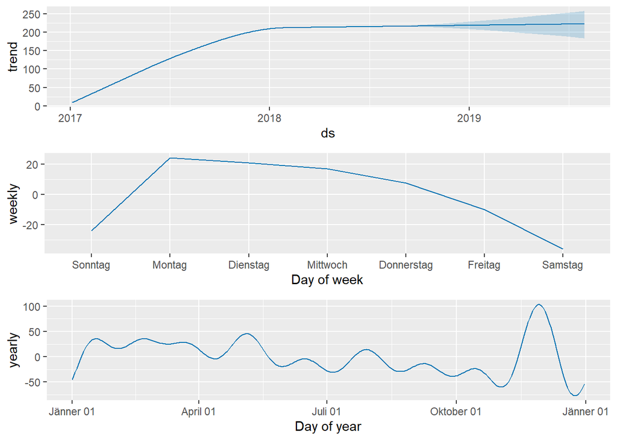

```r
prophet_plot_components(daily_orders_prophet, forecast) #plot ts components
```

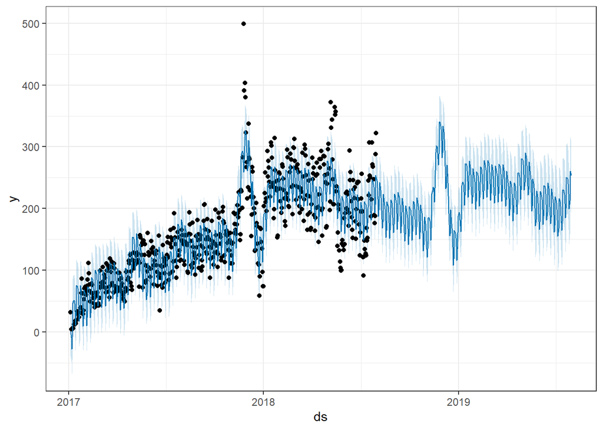

```r
plot(daily_orders_prophet, forecast) + #plot data and predictions
  theme_bw()
```

## Evaluating Performance

To evaluate the performance of the model, we compare the predictions for the first 15 days of August with the corresponding known values of daily orders.

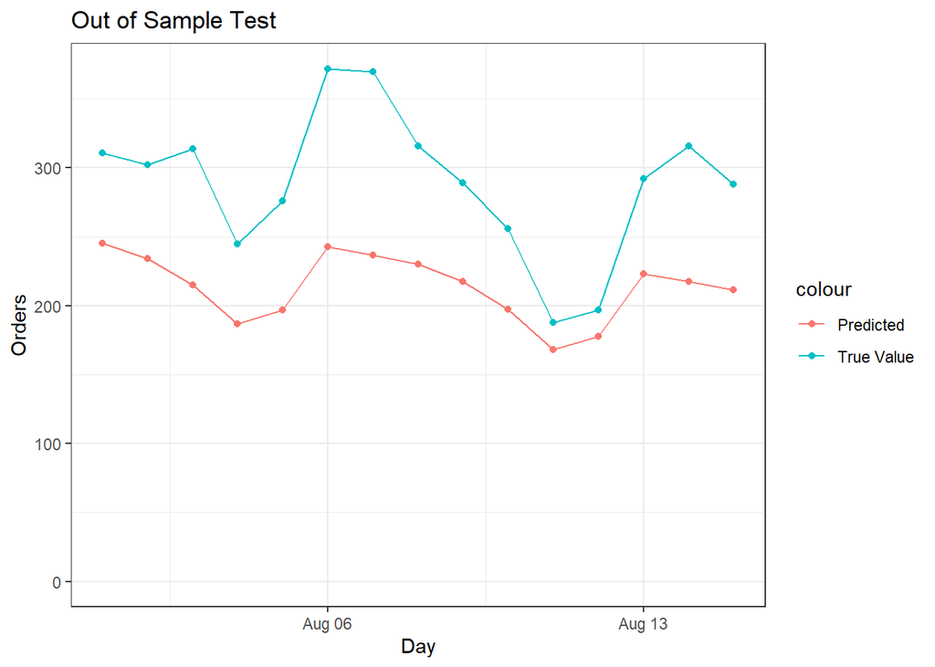

```r
out_of_sample <- data[[6]] %>%
  mutate(order_purchase_date = as_date(order_purchase_timestamp)) %>% #date of purchase
  group_by(order_purchase_date) %>% #group by date of purchase
  count() %>% #summarize
  filter(order_purchase_date >= "2018-08-01" &
           order_purchase_date < "2018-08-16") %>%
  left_join(forecast %>% mutate(ds = as_date(ds)), by = c("order_purchase_date" = "ds"))

# plot True vs. Predicted Values
out_of_sample %>%
  ggplot(., aes(x = order_purchase_date)) +
  geom_line(aes(y = n, color = "True Value")) +
  geom_point(aes(y = n, color = "True Value")) +
  geom_line(aes(y = yhat, color = "Predicted")) +
  geom_point(aes(y = yhat, color = "Predicted")) +
  theme_bw() +
  labs(x = "Day", y = "Orders", title = "Out of Sample Test") +
  expand_limits(y = 0)
```

```r
#test statistics
rmse <- sqrt(mean((out_of_sample$yhat - out_of_sample$n)^2))
mae <- mean(abs(out_of_sample$yhat - out_of_sample$n))
mape <-  mean(abs((out_of_sample$yhat - out_of_sample$n)/out_of_sample$n))
```

The out of sample test yields following results: Predictions for the first test period are on average 24.97 % lower than the actual error (Mean Absolute Percentage Error ~ MAPE). The Root Mean Squared Error (RMSE) is 81.57 Orders and the Mean Absolute Error (MAE) 75.4 Orders.

## Predicting Monthly Sales

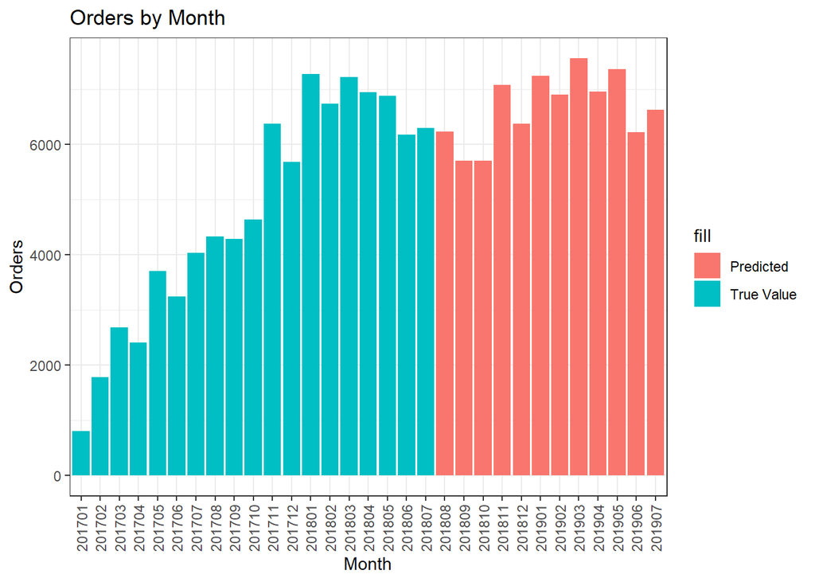

```r
future_orders_month <- forecast %>%
  filter(ds >= "2018-08-01") %>%
  transmute(order_purchase_date = as_date(ds),
            n = yhat) %>%
  mutate(order_purchase_month = format.Date(order_purchase_date, "%Y%m")) %>% #month of purchase
  group_by(order_purchase_month) %>% #group by date of purchase
  summarize(n = sum(n)) %>% #summarize
  arrange(order_purchase_month)

history_orders_month <- daily_orders %>%
  mutate(order_purchase_month = format.Date(order_purchase_date, "%Y%m")) %>% #month of purchase
  group_by(order_purchase_month) %>% #group by date of purchase
  summarize(n = sum(n)) %>% #summarize
  arrange(order_purchase_month)

ggplot(history_orders_month, aes(x = order_purchase_month, y = n)) +
  geom_col(aes(fill= "True Value")) +
  geom_col(data = future_orders_month, aes(fill= "Predicted")) +
  theme_bw() +
  labs(x = "Month", y = "Orders", title = "Orders by Month") +
  theme(axis.text.x = element_text(angle = 90, vjust = 0.5, hjust=1))
```